# Antone Evans Jr. and Abilash Vanam

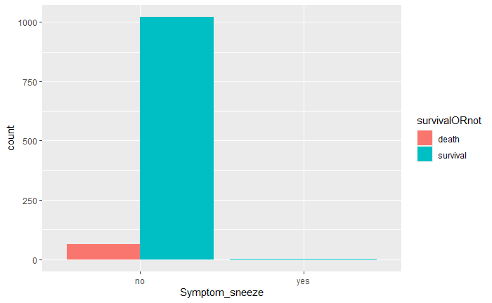

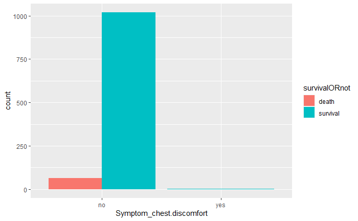

```r
ggplot(c19exploreData, aes(Symptom_chest.discomfort, ..count..)) + geom_bar(aes(fill = survivalORnot), position = "dodge")
```

```r
CrossTable(x=Symptom_thirst, y=survivalORnot, chisq = TRUE)
```

```
Chi-squared approximation may be incorrectChi-squared approximation may be incorrect
```

```
   Cell Contents
|-------------------------|
|                       N |
| Chi-square contribution |
|           N / Row Total |
|           N / Col Total |
|         N / Table Total |
|-------------------------|


Total Observations in Table:  1085


               | survivalORnot
Symptom_thirst |     death |  survival | Row Total |
---------------|-----------|-----------|-----------|
            no |        63 |      1021 |      1084 |
               |     0.000 |     0.000 |           |
               |     0.058 |     0.942 |     0.999 |
               |     1.000 |     0.999 |           |
               |     0.058 |     0.941 |           |
---------------|-----------|-----------|-----------|
           yes |         0 |         1 |         1 |
               |     0.058 |     0.004 |           |
               |     0.000 |     1.000 |     0.001 |
               |     0.000 |     0.001 |           |
               |     0.000 |     0.001 |           |
---------------|-----------|-----------|-----------|
  Column Total |        63 |      1022 |      1085 |
               |     0.058 |     0.942 |           |
---------------|-----------|-----------|-----------|


Statistics for All Table Factors


Pearson's Chi-squared test
------------------------------------------------------------
Chi^2 =  0.0617007     d.f. =  1     p =  0.8038278

Pearson's Chi-squared test with Yates' continuity correction
------------------------------------------------------------
Chi^2 =  5.103871e-26     d.f. =  1     p =  1
```

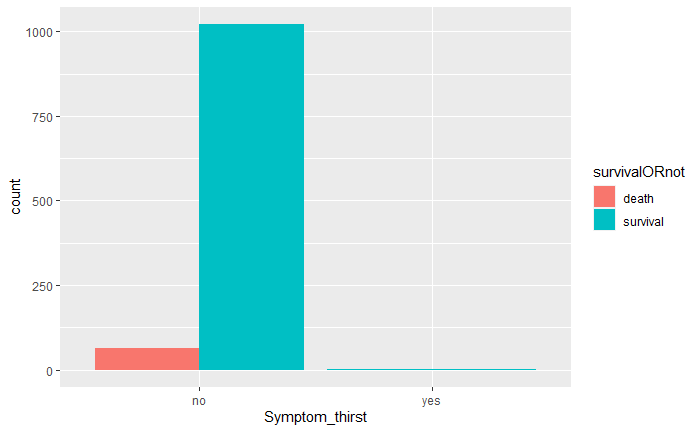

```r
ggplot(c19exploreData, aes(Symptom_thirst, ..count..)) + geom_bar(aes(fill = survivalORnot), position = "dodge")
```

```r
CrossTable(x=Symptom_flu.symptoms, y=survivalORnot, chisq = TRUE)
```

```
Chi-squared approximation may be incorrectChi-squared approximation may be incorrect
```

```
   Cell Contents
|-------------------------|
|                       N |
| Chi-square contribution |
|           N / Row Total |
|           N / Col Total |
|         N / Table Total |
|-------------------------|


Total Observations in Table:  1085


                     | survivalORnot
Symptom_flu.symptoms |     death |  survival | Row Total |
---------------------|-----------|-----------|-----------|
                  no |        63 |      1020 |      1083 |
                     |     0.000 |     0.000 |           |
                     |     0.058 |     0.942 |     0.998 |
                     |     1.000 |     0.998 |           |
                     |     0.058 |     0.940 |           |
---------------------|-----------|-----------|-----------|
                 yes |         0 |         2 |         2 |
                     |     0.116 |     0.007 |           |
                     |     0.000 |     1.000 |     0.002 |
                     |     0.000 |     0.002 |           |
                     |     0.000 |     0.002 |           |
---------------------|-----------|-----------|-----------|
        Column Total |        63 |      1022 |      1085 |
                     |     0.058 |     0.942 |           |
---------------------|-----------|-----------|-----------|


Statistics for All Table Factors


Pearson's Chi-squared test
------------------------------------------------------------
Chi^2 =  0.1235153     d.f. =  1     p =  0.7252526

Pearson's Chi-squared test with Yates' continuity correction
------------------------------------------------------------
Chi^2 =  8.086711e-32     d.f. =  1     p =  1
```

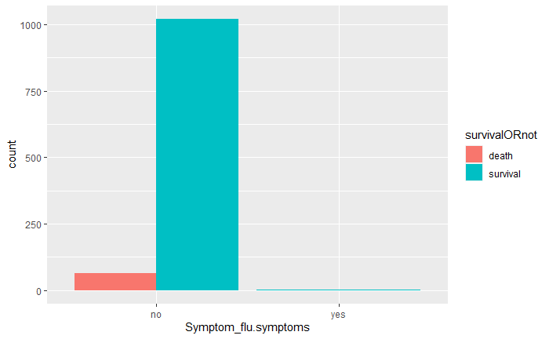

```r
ggplot(c19exploreData, aes(Symptom_flu.symptoms, ..count..)) + geom_bar(aes(fill = survivalORnot), position = "dodge")
```

```r
CrossTable(x=Symptom_muscle.cramps , y=survivalORnot, chisq = TRUE)
```

```
Chi-squared approximation may be incorrectChi-squared approximation may be incorrect
```

```
   Cell Contents
|-------------------------|
|                       N |
| Chi-square contribution |
|           N / Row Total |
|           N / Col Total |
|         N / Table Total |
|-------------------------|


Total Observations in Table:  1085


                      | survivalORnot
Symptom_muscle.cramps |     death |  survival | Row Total |
----------------------|-----------|-----------|-----------|
                   no |        63 |      1021 |      1084 |
                      |     0.000 |     0.000 |           |
                      |     0.058 |     0.942 |     0.999 |
                      |     1.000 |     0.999 |           |
                      |     0.058 |     0.941 |           |
----------------------|-----------|-----------|-----------|
                  yes |         0 |         1 |         1 |
                      |     0.058 |     0.004 |           |
                      |     0.000 |     1.000 |     0.001 |
                      |     0.000 |     0.001 |           |
                      |     0.000 |     0.001 |           |
----------------------|-----------|-----------|-----------|
         Column Total |        63 |      1022 |      1085 |
                      |     0.058 |     0.942 |           |
----------------------|-----------|-----------|-----------|


Statistics for All Table Factors


Pearson's Chi-squared test
------------------------------------------------------------
Chi^2 =  0.0617007     d.f. =  1     p =  0.8038278

Pearson's Chi-squared test with Yates' continuity correction
------------------------------------------------------------
Chi^2 =  5.103871e-26     d.f. =  1     p =  1
```

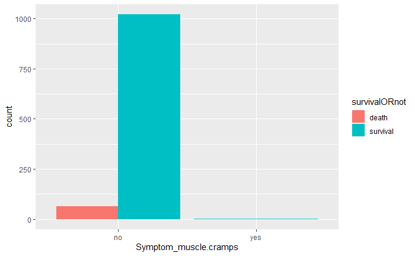

```r
ggplot(c19exploreData, aes(Symptom_muscle.cramps , ..count..)) + geom_bar(aes(fill = survivalORnot), position = "dodge")
```

```r
CrossTable(x=Symptom_reflux , y=survivalORnot, chisq = TRUE)
```

```
Chi-squared approximation may be incorrectChi-squared approximation may be incorrect
```

```
   Cell Contents
|-------------------------|
|                       N |
| Chi-square contribution |
|           N / Row Total |
|           N / Col Total |
|         N / Table Total |
|-------------------------|


Total Observations in Table:  1085


               | survivalORnot
Symptom_reflux |     death |  survival | Row Total |
---------------|-----------|-----------|-----------|
            no |        63 |      1021 |      1084 |
               |     0.000 |     0.000 |           |
               |     0.058 |     0.942 |     0.999 |
               |     1.000 |     0.999 |           |
               |     0.058 |     0.941 |           |
---------------|-----------|-----------|-----------|
           yes |         0 |         1 |         1 |
               |     0.058 |     0.004 |           |
               |     0.000 |     1.000 |     0.001 |
               |     0.000 |     0.001 |           |
               |     0.000 |     0.001 |           |
---------------|-----------|-----------|-----------|
  Column Total |        63 |      1022 |      1085 |
               |     0.058 |     0.942 |           |
---------------|-----------|-----------|-----------|


Statistics for All Table Factors


Pearson's Chi-squared test
------------------------------------------------------------
Chi^2 =  0.0617007     d.f. =  1     p =  0.8038278

Pearson's Chi-squared test with Yates' continuity correction
------------------------------------------------------------
Chi^2 =  5.103871e-26     d.f. =  1     p =  1
```

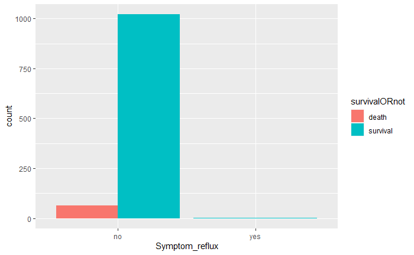

```r
ggplot(c19exploreData, aes(Symptom_reflux , ..count..)) + geom_bar(aes(fill = survivalORnot), position = "dodge")
```

```r
CrossTable(x=Symptom_physical.discomfort , y=survivalORnot, chisq = TRUE)
```

```
Chi-squared approximation may be incorrectChi-squared approximation may be incorrect
```

```
   Cell Contents
|-------------------------|
|                       N |
| Chi-square contribution |
|           N / Row Total |
|           N / Col Total |
|         N / Table Total |
|-------------------------|


Total Observations in Table:  1085


                            | survivalORnot
Symptom_physical.discomfort |     death |  survival | Row Total |
----------------------------|-----------|-----------|-----------|
                         no |        63 |      1021 |      1084 |
                            |     0.000 |     0.000 |           |
                            |     0.058 |     0.942 |     0.999 |
                            |     1.000 |     0.999 |           |
                            |     0.058 |     0.941 |           |
----------------------------|-----------|-----------|-----------|
                        yes |         0 |         1 |         1 |
                            |     0.058 |     0.004 |           |
                            |     0.000 |     1.000 |     0.001 |
                            |     0.000 |     0.001 |           |
                            |     0.000 |     0.001 |           |
----------------------------|-----------|-----------|-----------|
               Column Total |        63 |      1022 |      1085 |
                            |     0.058 |     0.942 |           |
----------------------------|-----------|-----------|-----------|


Statistics for All Table Factors


Pearson's Chi-squared test
------------------------------------------------------------
Chi^2 =  0.0617007     d.f. =  1     p =  0.8038278

Pearson's Chi-squared test with Yates' continuity correction
------------------------------------------------------------
Chi^2 =  5.103871e-26     d.f. =  1     p =  1
```

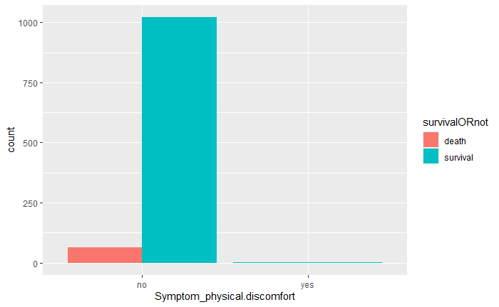

```r
ggplot(c19exploreData, aes(Symptom_physical.discomfort , ..count..)) + geom_bar(aes(fill = survivalORnot), position = "dodge")
```

```r
CrossTable(x=Symptom_itchy.throat , y=survivalORnot, chisq = TRUE)
```

```
Chi-squared approximation may be incorrectChi-squared approximation may be incorrect
```

```
   Cell Contents
|-------------------------|
|                       N |
| Chi-square contribution |
|           N / Row Total |
|           N / Col Total |
|         N / Table Total |
|-------------------------|


Total Observations in Table:  1085


                     | survivalORnot
Symptom_itchy.throat |     death |  survival | Row Total |
---------------------|-----------|-----------|-----------|
                  no |        63 |      1021 |      1084 |
                     |     0.000 |     0.000 |           |
                     |     0.058 |     0.942 |     0.999 |
                     |     1.000 |     0.999 |           |
                     |     0.058 |     0.941 |           |
---------------------|-----------|-----------|-----------|
                 yes |         0 |         1 |         1 |
                     |     0.058 |     0.004 |           |
                     |     0.000 |     1.000 |     0.001 |
                     |     0.000 |     0.001 |           |
                     |     0.000 |     0.001 |           |
---------------------|-----------|-----------|-----------|
        Column Total |        63 |      1022 |      1085 |
                     |     0.058 |     0.942 |           |
---------------------|-----------|-----------|-----------|


Statistics for All Table Factors


Pearson's Chi-squared test
------------------------------------------------------------
Chi^2 =  0.0617007     d.f. =  1     p =  0.8038278

Pearson's Chi-squared test with Yates' continuity correction
------------------------------------------------------------
Chi^2 =  5.103871e-26     d.f. =  1     p =  1
```

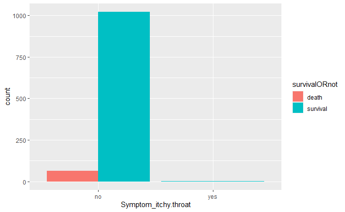

```r
ggplot(c19exploreData, aes(Symptom_itchy.throat , ..count..)) + geom_bar(aes(fill = survivalORnot), position = "dodge")
```

##### Exploring Numerical Variables

```r
t.test(c19exploreData$age ~ c19exploreData$survivalORnot,alternative="two.sided")
```

```
    Welch Two Sample t-test

data:  c19exploreData$age by c19exploreData$survivalORnot
t = 10.601, df = 71.865, p-value = 2.423e-16
alternative hypothesis: true difference in means is not equal to 0
95 percent confidence interval:
 15.98790 23.39393
sample estimates:
   mean in group death mean in group survival
              66.93651               47.24560
```

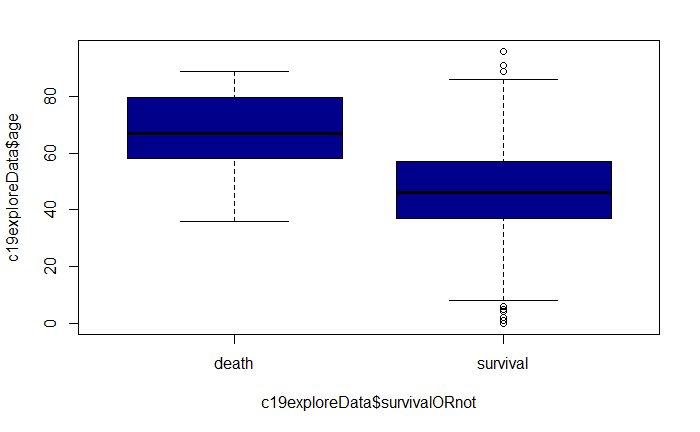

```r
plot(c19exploreData$age ~ c19exploreData$survivalORnot, col="darkblue")
```

```r
t.test(c19exploreData$symptomLength ~ c19exploreData$survivalORnot,alternative="two.sided")
```

```
    Welch Two Sample t-test

data:  c19exploreData$symptomLength by c19exploreData$survivalORnot
t = 6.9569, df = 64.126, p-value = 2.195e-09
alternative hypothesis: true difference in means is not equal to 0
95 percent confidence interval:
 4.803795 8.673889
sample estimates:
   mean in group death mean in group survival
             13.563039               6.824197
```

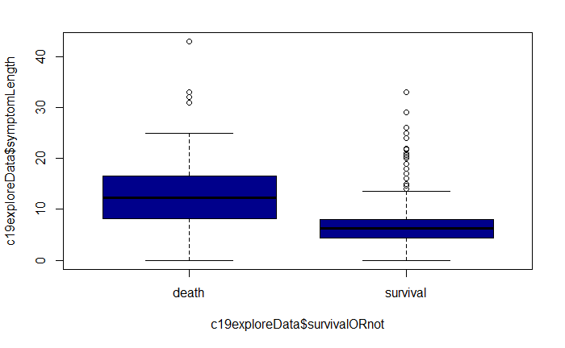

```r
plot(c19exploreData$symptomLength ~ c19exploreData$survivalORnot, col="darkblue")
```

```r
t.test(c19exploreData$reportingLength ~ c19exploreData$survivalORnot,alternative="two.sided")
```

```
    Welch Two Sample t-test

data:  c19exploreData$reportingLength by c19exploreData$survivalORnot
t = 5.7023, df = 64.681, p-value = 3.164e-07
alternative hypothesis: true difference in means is not equal to 0
95 percent confidence interval:
 2.748570 5.712063
sample estimates:
   mean in group death mean in group survival
              8.248093               4.017776
```

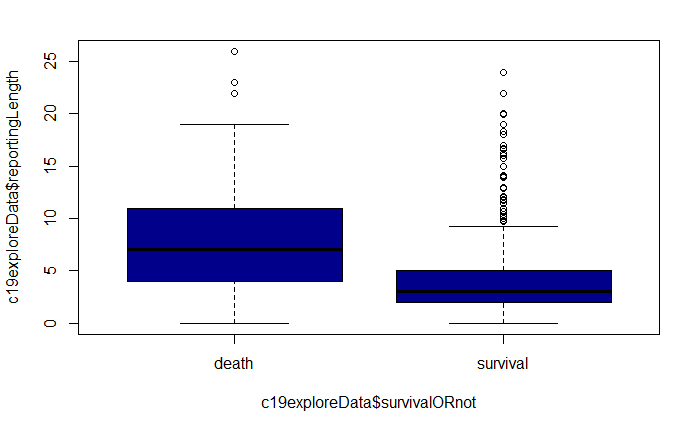

```r
plot(c19exploreData$reportingLength ~ c19exploreData$survivalORnot, col="darkblue")
```

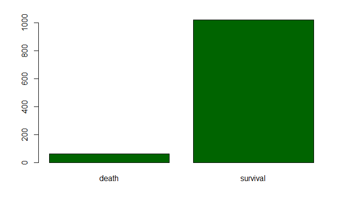

```r
plot(c19exploreData$survivalORnot, col="darkgreen")
```

# Training and Evaluation of ML models

### Data Scaling Training and Testing

##### Use Caret’s “createDataPartition” method to partition the dataset into 80% for training and 20% for testing

```r
library(caret)
train.index=createDataPartition(c19$death,p = 0.8, list = FALSE)
c19_train=c19[train.index, ]
c19_test <- c19[-train.index, ]
```

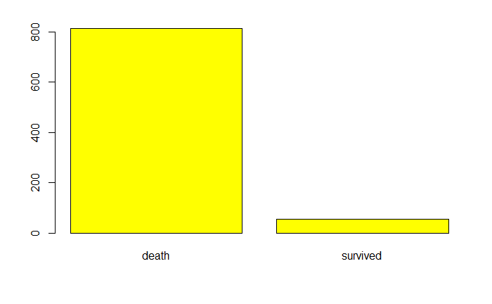

```r
c19train_labels = ifelse(c19_train$death == 0, "death", "survived")
c19train_labels = as.data.frame(c19train_labels)
plot(c19train_labels, col="yellow")
```

```r
library(DMwR)
set.seed(1)
c19_train$death = as.factor(c19_train$death)
c19_train <- SMOTE(death ~ ., data  = c19_train)
```

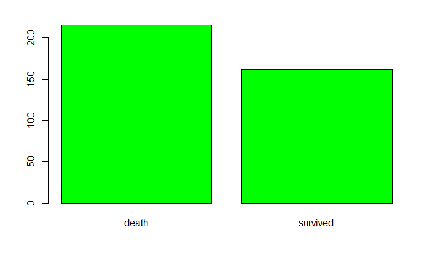

```r
smote_labels = ifelse(c19_train$death == 0, "death", "survived")
smote_labels = as.data.frame(smote_labels)
plot(smote_labels, col="green")
```

```r
train_labels = c19_train$death
test_labels = c19_test$death
```

```r
algorithm = 0
accuary = 0
kappa = 0
auc = 0
fnr = 0
AllData= cbind.data.frame(algorithm,accuary,kappa,auc,fnr)
AllData = as.data.frame(AllData)
```

### b.Regularized logistic regression

#### Lasso

##### set.seed(1) and train the model using 10 fold cross validation and tune lambda. Compute the confusion matrix from each model and compute accuracy, AUC and if data is imbalance compute the kappa.

```r
c19_train$death = as.factor(c19_train$death)
c19_test$death = as.factor(c19_test$death)
```

```r
library(ROCR)
set.seed(1)

lasso <- train(
  death ~., data = c19_train, method = "glmnet",
  trControl = trainControl("cv", number = 10),
  tuneGrid = expand.grid(alpha = 1, lambda = 10^seq(-3, 3, length = 100)))

lasso_predictions=predict(lasso, c19_test)
lassoCM = confusionMatrix(lasso_predictions,c19_test$death)
lassoCM
```

```
Confusion Matrix and Statistics

          Reference
Prediction   0   1
         0 192   3
         1  16   6

               Accuracy : 0.9124
                 95% CI : (0.8666, 0.9465)
    No Information Rate : 0.9585
    P-Value [Acc > NIR] : 0.999206

                  Kappa : 0.3488

 Mcnemar's Test P-Value : 0.005905

            Sensitivity : 0.9231
            Specificity : 0.6667
         Pos Pred Value : 0.9846
         Neg Pred Value : 0.2727
             Prevalence : 0.9585
         Detection Rate : 0.8848
   Detection Prevalence : 0.8986
      Balanced Accuracy : 0.7949

       'Positive' Class : 0
```

```r
lasso_predictions_prob=predict(lasso, c19_test, type="prob")

pred_m_lasso=prediction(lasso_predictions_prob$`1`,c19_test$death)
lassoAUC = performance(pred_m_lasso, measure = "auc")@y.values
```

```r
lassoFNR = lassoCM$table[2] / (lassoCM$table[2] + lassoCM$table[4])
```

```r
lasso.add = c("lasso", lassoCM$overall["Accuracy"], lassoCM$overall["Kappa"], lassoAUC[1], lassoFNR)
names(lasso.add) = c("algorithm","accuary","kappa","auc","fnr")
AllData = rbind(lasso.add)
AllData = as.data.frame(AllData)
```

##### Did Lasso shrink any variables to 0? If so, report these variables.

```r
coef(lasso$finalModel, lasso$bestTune$lambda)
```

```
78 x 1 sparse Matrix of class "dgCMatrix"
                                             1
(Intercept)                      -14.296886311
countryAlgeria                     .
countryAustralia                   .
countryAustria                     .
countryBahrain                     .
countryBelgium                     .
countryCambodia                    .
countryCanada                      .
countryChina                       4.049554667
countryCroatia                     .
countryEgypt                       .
countryFinland                     .
countryFrance                      3.332274447
countryGermany                     .
countryHong Kong                   0.812082286
countryIndia                       .
countryIran                        4.011311148
countryIsrael                      .
countryItaly                       .
countryJapan                      -0.809419803
countryKuwait                      .
countryLebanon                     .
countryMalaysia                    .
countryNepal                       .
countryPhillipines                 5.640169950
countryRussia                      .
countrySingapore                  -5.623225247
countrySouth Korea                 4.577487262
countrySpain                       .
countrySri Lanka                   .
countrySweden                      .
countrySwitzerland                -2.199602838
countryTaiwan                     -1.739200909
countryThailand                   -0.186873895
countryUAE                        -0.969527237
countryUK                          .
countryUSA                         .
countryVietnam                     .
```

[output cut: 25 more lines]

```
Symptom_sputum                    -6.718512254
Symptom_myalgia                   14.040217085
Symptom_sore.throat               -0.022686306
Symptom_dyspnea                    0.005529288
Symptom_nausea                     .
Symptom_respiratory.distress       .
Symptom_throat.discomfort          .
Symptom_sneeze                     .
Symptom_chest.discomfort           .
Symptom_thirst                     .
Symptom_flu.symptoms               .
Symptom_muscle.cramps              .
Symptom_reflux                     .
Symptom_physical.discomfort        .
Symptom_itchy.throat               .
```

#### Ridge

##### set.seed(1) and train the model using 10 fold cross validation and tune lambda. Compute the confusion matrix from each model and compute accuracy, AUC and if data is imbalance compute the kappa.

```r
set.seed(1)
ridge <- train(
  death~., data = c19_train, method = "glmnet",
    trControl = trainControl("cv", number = 10),
    tuneGrid = expand.grid(alpha = 0, lambda = 10^seq(-3, 3, length = 100)))

ridge_predictions=predict(ridge, c19_test)
ridgeCM = confusionMatrix(ridge_predictions,c19_test$death)
ridgeCM
```

```
Confusion Matrix and Statistics

          Reference
Prediction   0   1
         0 194   3
         1  14   6

               Accuracy : 0.9217
                 95% CI : (0.8775, 0.9537)
    No Information Rate : 0.9585
    P-Value [Acc > NIR] : 0.99560

                  Kappa : 0.3782

 Mcnemar's Test P-Value : 0.01529

            Sensitivity : 0.9327
            Specificity : 0.6667
         Pos Pred Value : 0.9848
         Neg Pred Value : 0.3000
             Prevalence : 0.9585
         Detection Rate : 0.8940
   Detection Prevalence : 0.9078
      Balanced Accuracy : 0.7997

       'Positive' Class : 0
```

```r
ridge_predictions_prob=predict(ridge, c19_test, type="prob")

pred_m_ridge=prediction(ridge_predictions_prob$`1`,c19_test$death)
ridgeAUC = performance(pred_m_ridge, measure = "auc")@y.values
```

```r
ridgeFNR = ridgeCM$table[2] / (ridgeCM$table[2] + ridgeCM$table[4])
```

```r
ridge.add = c("ridge", ridgeCM$overall["Accuracy"], ridgeCM$overall["Kappa"], ridgeAUC[1], ridgeFNR)
names(ridge.add) = c("algorithm","accuary","kappa","auc","fnr")
AllData = rbind(AllData, ridge.add)
AllData = as.data.frame(AllData)
```

#### Elastic net

##### set.seed(1) and train the model using 10 fold cross validation and tune lambda and alpha. Compute the confusion matrix from each model and compute accuracy, AUC and if data is imbalance compute the kappa.

```r
set.seed(1)
enet <- train(
     death ~., data = c19_train, method = "glmnet",
     trControl = trainControl("cv", number = 10),
     tuneGrid = expand.grid(alpha =seq(0,1, length=10), lambda = 10^seq(-3, 3, length = 100)))

enet_predictions=predict(enet, c19_test)
enetCM = confusionMatrix(enet_predictions,c19_test$death)
enetCM
```

```
Confusion Matrix and Statistics

          Reference
Prediction   0   1
         0 192   3
         1  16   6

               Accuracy : 0.9124
                 95% CI : (0.8666, 0.9465)
    No Information Rate : 0.9585
    P-Value [Acc > NIR] : 0.999206

                  Kappa : 0.3488

 Mcnemar's Test P-Value : 0.005905

            Sensitivity : 0.9231
            Specificity : 0.6667
         Pos Pred Value : 0.9846
         Neg Pred Value : 0.2727
             Prevalence : 0.9585
         Detection Rate : 0.8848
   Detection Prevalence : 0.8986
      Balanced Accuracy : 0.7949

       'Positive' Class : 0
```

```r
enet_predictions_prob=predict(enet, c19_test, type="prob")

pred_m_enet=prediction(enet_predictions_prob$`1`,c19_test$death)
enetAUC = performance(pred_m_enet, measure = "auc")@y.values
```

```r
enetFNR = enetCM$table[2] / (enetCM$table[2] + enetCM$table[4])
```

```r
enet.add = c("enet", enetCM$overall["Accuracy"], enetCM$overall["Kappa"], enetAUC[1], enetFNR)
names(enet.add) = c("algorithm","accuary","kappa","auc","fnr")
AllData = rbind(AllData, enet.add)
AllData = as.data.frame(AllData)
```